# CS5324Lab1-3

## **United States Prisons**

Lab 1: Exploring Table Data - Fall 2023  
**Simba Masters**  
**Reese Mellor**  
**Kenny Zhang**

## **1. Business Understanding**

With the rise of Criminal Justice reform and the Black Lives Matter movement, the US justice system has become a point of interest for many Americans. America also has large amount of prisons. Prison Policy Initiative found that “Together, these systems hold almost 2 million people in 1,566 state prisons, 98 federal prisons, 3,116 local jails, 1,323 juvenile correctional facilities, 181 immigration detention facilities, and 80 Indian country jails, as well as in military prisons, civil commitment centers, state psychiatric hospitals, and prisons in the U.S. territories” (Sawyer & Wagner, 2023). Thus, if someone does not sit behind bars themselves, it is still highly likely that the United States prison system has had an impact on their lives.

This data set was populated from “open source search methodologies of authoritative sources,” which is a way of using established and credible techniques to search for public yet reliable information. It was originally populated to “describe the extent of where the incarcerated population is located” and to “describe many physical and social characteristics of detention facilities in the United States…” ("Prison Boundaries", 2020). To clarify and hone in on important information that may be categorized as identity or location, several attributes have been dropped from the following analysis. The facility's id, state, type, population, security level, and capacity have all been kept.

The predictive task is illustrating which states need more or less prisons based upon the comparison of the population and capacity attributes. The analysis may be deemed useful to third parties when the locations that not only hold the most prisons but the most inmates are analyzed as this may allow citizens to better understand the overcrowding processes of prisons and may direct movement leaders and prison owners to specific areas of the country.

## **2. Data Understanding**

### **2.1 Data Description**

```python
# Import packages
import numpy as np                # for efficient numerical computations
import pandas as pd               # for DataFrame
import seaborn as sns

# Avoids warning messages
import warnings
warnings.filterwarnings('ignore')

# for visualization
import matplotlib.pyplot as plt
%matplotlib inline

df_pb = pd.read_csv("./data/Prison_Boundaries.csv")

# Dropping empty last row
df_pb.drop(index=[len(df_pb.index) - 1], inplace = True)

# Dropping prisons outside of the US
df_pb = df_pb[df_pb.COUNTRY == 'USA']

# Dropping unnecessary columns
df_pb.drop(columns=['NAME', 'CITY', 'COUNTY', 'FID', 'ADDRESS', 'ZIP', 'ZIP4', 'TELEPHONE', 'STATUS', 'COUNTYFIPS', 'COUNTRY', 'NAICS_CODE',
                    'NAICS_DESC', 'SOURCE', 'SOURCEDATE', 'VAL_METHOD', 'VAL_DATE', 'WEBSITE', 'SHAPE_Leng', 'GlobalID',
                    'CreationDate', 'Creator', 'EditDate', 'Editor', 'SHAPE_Length', 'SHAPE_Area'], inplace = True)

# Replace prison security level to numerical indicator
df_pb.SECURELVL.replace(to_replace = ['JUVENILE', 'MINIMUM', 'MEDIUM', 'CLOSE', 'MAXIMUM'], value = range(1,6), inplace = True)

# Replaced 'NOT AVAILABLE' and -999 values to NaN
df_pb.replace(to_replace = ['NOT AVAILABLE'], value = np.NaN, inplace = True)
df_pb.replace(to_replace = [-999], value = np.NaN, inplace = True)

# Sort List alphabetically by state
df_pb = df_pb.sort_values(by='STATE')

# Reset index
df_pb = df_pb.reset_index(drop=True)

pd.set_option('display.float_format', lambda x: '%.2f' % x) # Format output
df_pb
```

|  | FACILITYID | STATE | TYPE | POPULATION | SECURELVL | CAPACITY |
| --- | --- | --- | --- | --- | --- | --- |
| 0 | 10003760.00 | AK | LOCAL | NaN | NaN | 14.00 |
| 1 | 10006386.00 | AK | STATE | 1125.00 | 3.00 | 1536.00 |
| 2 | 10003764.00 | AK | STATE | 49.00 | NaN | 58.00 |
| 3 | 10001242.00 | AK | STATE | 19.00 | 1.00 | 20.00 |
| 4 | 10001241.00 | AK | STATE | 209.00 | 5.00 | 232.00 |
| ... | ... | ... | ... | ... | ... | ... |
| 6685 | 10006189.00 | WY | STATE | 655.00 | 5.00 | 722.00 |
| 6686 | 10001894.00 | WY | COUNTY | NaN | NaN | NaN |
| 6687 | 10001885.00 | WY | COUNTY | NaN | NaN | NaN |
| 6688 | 10001883.00 | WY | COUNTY | NaN | NaN | 106.00 |
| 6689 | 10001890.00 | WY | COUNTY | NaN | NaN | NaN |

6690 rows × 6 columns

```python
df_pb.describe()
```

|  | FACILITYID | POPULATION | SECURELVL | CAPACITY |
| --- | --- | --- | --- | --- |
| count | 6690.00 | 4780.00 | 3844.00 | 5038.00 |
| mean | 10003495.06 | 430.57 | 2.66 | 475.77 |
| std | 2027.45 | 681.71 | 1.55 | 692.17 |
| min | 10000001.00 | 0.00 | 1.00 | 1.00 |
| 25% | 10001744.25 | 26.00 | 1.00 | 57.00 |
| 50% | 10003479.50 | 142.00 | 2.00 | 180.00 |
| 75% | 10005258.75 | 537.00 | 4.00 | 612.00 |
| max | 10007020.00 | 8216.00 | 5.00 | 10000.00 |

```python
# Create a data description table
data_des = pd.DataFrame()

data_des['Features'] = df_pb.columns
data_des['Description'] = ['the facility\'s ID', 'state the prison is in', 'type of prison',
                           'number of current prisoners', 'security level of the prison',
                           'total prisoner capacity']
data_des['Scales'] = ['norminal'] * 3 + ['ratio'] + ['ordinal'] + ['ratio']
data_des['Discrete\Continuous'] = ['discrete'] * 6
data_des['Range'] = ['10000001 - 10007020', repr(set(df_pb.STATE)), 'local, county, state, federal, multi', '0 - 8216',
                     '1: juvenile; 2: minimum; 3: medium, 4: close, 5: maximum', '1 - 10,000']
data_des
```

|  | Features | Description | Scales | Discrete\Continuous | Range |
| --- | --- | --- | --- | --- | --- |
| 0 | FACILITYID | the facility's ID | norminal | discrete | 10000001 - 10007020 |
| 1 | STATE | state the prison is in | norminal | discrete | {'MN', 'VA', 'ME', 'OK', 'CO', 'AR', 'CA', 'DC... |
| 2 | TYPE | type of prison | norminal | discrete | local, county, state, federal, multi |
| 3 | POPULATION | number of current prisoners | ratio | discrete | 0 - 8216 |
| 4 | SECURELVL | security level of the prison | ordinal | discrete | 1: juvenile; 2: minimum; 3: medium, 4: close, ... |
| 5 | CAPACITY | total prisoner capacity | ratio | discrete | 1 - 10,000 |

The table above describes each entries features, as well as the features' description, scale, and range.

### **2.2 Data Quality**

Before we begin analyzing and visualizing this data, let's assess its quality.  
Extraneous columns have already been removed. With that done, let's check for missing values.

```python
print (df_pb.info())
```

```
<class 'pandas.core.frame.DataFrame'>
RangeIndex: 6690 entries, 0 to 6689
Data columns (total 6 columns):
 #   Column      Non-Null Count  Dtype
---  ------      --------------  -----
 0   FACILITYID  6690 non-null   float64
 1   STATE       6690 non-null   object
 2   TYPE        6667 non-null   object
 3   POPULATION  4780 non-null   float64
 4   SECURELVL   3844 non-null   float64
 5   CAPACITY    5038 non-null   float64
dtypes: float64(4), object(2)
memory usage: 313.7+ KB
None
```

As shown here, there is a large amount of entries with missing values. A majority of the missing values are in the population, security level, and capacity columns. We decided to keep these entries in regardless because entries are very rarely missing all three of these attributes. As such, these entries still have value in contributing these attributes when such an attribute is not needed. However, when a missing attribute is needed, the entry can be excluded.  
Now, let's check for duplicate entries.

```python
# find duplicate instances
idx = df_pb.duplicated()

# length of duplicate list
len(df_pb[idx])
```

```
0
```

As shown above, there are no duplicate entries.

## **3. Data Visualization**

### **3.1 Data Exploration**

#### 3 Questions to Answer:

Upon researching the United States prison systems, we began to discuss the large amount of impactful factors. This includes but is not limited to state and federal politics, the average belief of criminal penalities, and the primary targets influential organizations. This led us to asking three primary issues:

```
Question 1: Which states have too many or too little prisons?
Question 2: Which states are more at risk of overcrowding in prisons?
Question 3: Which types of prisons are more prominent on a national basis?
```

#### **3.1.1 Categorical Distribution of Security Levels in US Prisons**

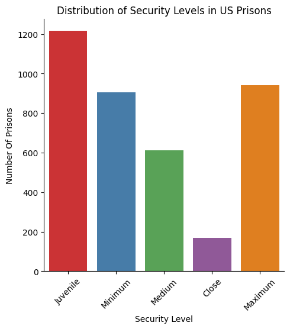

```python
# import seaborn
import seaborn as sns

df_sl = df_pb.groupby('SECURELVL').size().reset_index(name='Counts')
secLevels = ['Juvenile', 'Minimum', 'Medium', 'Close', 'Maximum']

# Create a categorical distribution plot of the security levels
sns.catplot(x="SECURELVL", y="Counts", kind="bar", data=df_sl, palette="Set1")

ax = plt.gca()
ax.set_xticklabels(secLevels, rotation=45)

plt.xlabel("Security Level")
plt.ylabel("Number Of Prisons")
plt.title("Distribution of Security Levels in US Prisons")
```

#### **3.1.2 Distribution of Prison Security Levels by State**

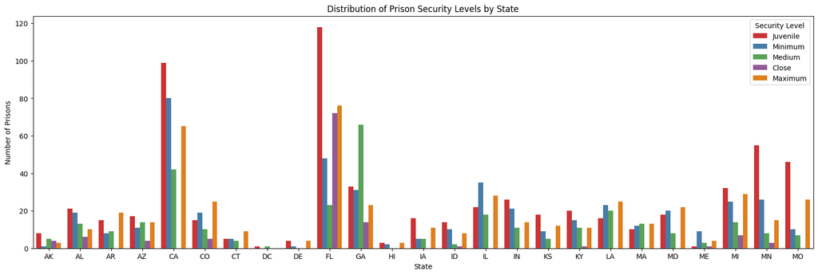

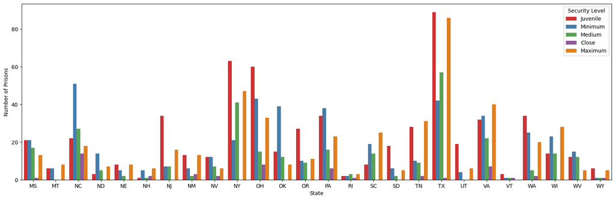

```python
df_sorted = df_pb.sort_values(by='STATE').reset_index()
missouri_index = df_sorted[df_sorted['STATE'] == 'MS'].index[0]
states_before_missouri = df_sorted.iloc[:missouri_index]

first_half = df_sorted.iloc[:missouri_index]
second_half = df_sorted.iloc[missouri_index:]

# Create first half bar chart
plt.figure(figsize=(20, 6))
sns.countplot(x='STATE', hue='SECURELVL', data=first_half, palette='Set1')
plt.xlabel('State')
plt.ylabel('Number of Prisons')
plt.title('Distribution of Prison Security Levels by State')
plt.legend(['Juvenile', 'Minimum', 'Medium', 'Close', 'Maximum'], title='Security Level')
plt.show()

# Create second half chart
plt.figure(figsize=(20, 6))
sns.countplot(x='STATE', hue='SECURELVL', data=second_half, palette='Set1')
plt.xlabel('State')
plt.ylabel('Number of Prisons')
plt.legend(['Juvenile', 'Minimum', 'Medium', 'Close', 'Maximum'], title='Security Level')
plt.show()
```

#### **3.1.3 Distribution of States in Dataset**

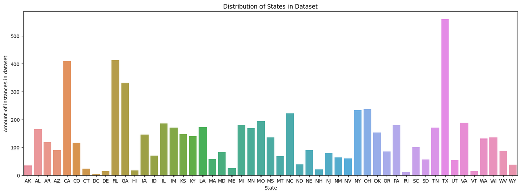

```python
# Read in csv of state populations (April 2020)
df_pop = pd.read_csv("./data/State_Population_April_2020.csv")

# Convert string representation of numbers to integers
ar_pop = df_pop['Population'].to_numpy()
ar_pop = np.array([int(x.replace(',', '')) for x in ar_pop])
df_pop.Population = ar_pop

# Rename column to match prison dataset
df_pop = df_pop.rename(columns={'State': 'STATE'})

# Plot initialization
plt.figure(figsize=(18, 6))
countplot = sns.countplot(x ='STATE', data = df_pb)

# Add labels to plot
plt.xlabel("State")
plt.ylabel("Amount of instances in dataset")
plt.title("Distribution of States in Dataset")

plt.show();
```

**Figure 3:** California, Florida, Georgia, and Texas have the most prisons out of all the other states. While California, Florida, and Texas make sense due to their high populations, Georgia is not known for having a large population which makes its amount of prisons unusual.

#### **3.1.4 Amount of Prisons Versus Population per State**

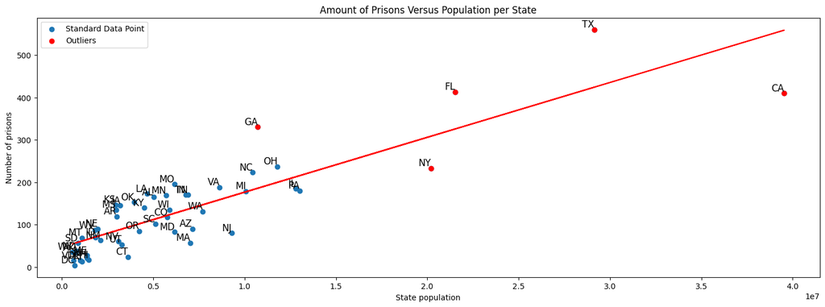

```python
# Get the counts of each state
state_counts = df_pb.groupby('STATE').size().reset_index(name='Counts')

# Merge state_counts and df_pop based on the 'STATE' column, pc = popcount
df_pc = pd.merge(state_counts, df_pop, on='STATE', how='inner')

# Calculate z-scores for X and Y
z_scores_x = (df_pc['Population'] - df_pc['Population'].mean()) / df_pc['Population'].std()
z_scores_y = (df_pc['Counts'] - df_pc['Counts'].mean()) / df_pc['Counts'].std()

# Identify outliers based on the z-score threshold
z_threshold = 1.5
outliers = df_pc[(np.abs(z_scores_x) > z_threshold) | (np.abs(z_scores_y) > z_threshold)]

# Plot scatterplot
plt.figure(figsize=(18, 6))
plt.scatter(y = df_pc.Counts, x = df_pc.Population, label='Standard Data Point')
plt.scatter(outliers['Population'], outliers['Counts'], color='red', label='Outliers')
plt.legend()

# Create regression line using polynomial fit
coefficients = np.polyfit(df_pc.Population, df_pc.Counts, 1)
slope, intercept = coefficients
regression_line = [slope * xi + intercept for xi in df_pc.Population]

# Plot the regression line
plt.plot(df_pc.Population, regression_line, color='red', label='Line of Best Fit')

# Label each point with the corresponding state name
for i, state in enumerate(df_pc.STATE):
    plt.text(df_pc.Population[i], df_pc.Counts[i], state, fontsize=12, ha='right', va='bottom')

# Add labels to plot
plt.ylabel("Number of prisons")
plt.xlabel("State population")
plt.title("Amount of Prisons Versus Population per State")

plt.show();
```

**Figure 4:** It is makes sense that California, Texas, Florida, and New York would be outliers since they have the largest populations. However, Georgia is unique in that it's status as an outlier is due to its large amount of prisons rather than its population. This confirms our suspicions from the last graph. It can be interpereted that states above the regression line have too many prisons while states under the regression line need more prisons in order to avoid overcrowding. However, the regression line may have been skewed by our outliers.

#### **3.1.5 Amount of Prisons Versus Population per State (No Outliers)**

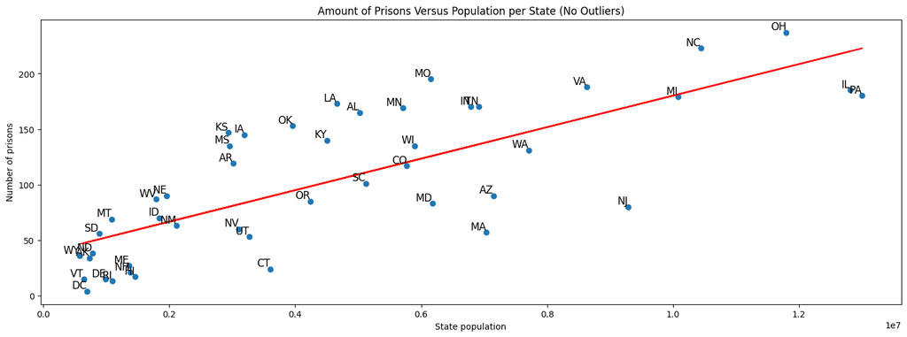

```python
# List of states to drop
outliers = ['CA', 'TX', 'FL', 'NY', 'GA']

# No outliers
df_pcno = df_pc

# Drop rows for the specified states
df_pcno = df_pc[~df_pc['STATE'].isin(outliers)]
df_pcno = df_pcno.reset_index()

# Plot scatterplot
plt.figure(figsize=(18, 6))
plt.scatter(y = df_pcno.Counts, x = df_pcno.Population)

# Create new regression line using modified data
coefficients = np.polyfit(df_pcno.Population, df_pcno.Counts, 1)
slope, intercept = coefficients
regression_line = [slope * xi + intercept for xi in df_pcno.Population]

# Plot regression line
plt.plot(df_pcno.Population, regression_line, color='red', label='Line of Best Fit')

# Label each point with the corresponding state name
for i, state in enumerate(df_pcno.STATE):
    plt.text(df_pcno.Population[i], df_pcno.Counts[i], state, fontsize=12, ha='right', va='bottom')

# Add labels to plot
plt.ylabel("Number of prisons")
plt.xlabel("State population")
plt.title("Amount of Prisons Versus Population per State (No Outliers)")

plt.show();
```

**Figure 5:** This scatterplot recalculates the regression line after excluding the previously identified outliers. Many states on the east coast are plotted in the bottom left corner with low populations and low prison quantity. Meanwhile, states located above the regression line in the upper right, including Ohio and North Carolina, have disproportionately higher amounts of prisons for their populations. This may be due to the political affiliations of each state. States that have historically been red states often have stricter drug laws and harsher penalties for violations of drug laws, due to the Republican parties stance on drugs. This trend is reflected in the placement of the regression line, as states above the line are generally conservative states, while the states under the line are generally progressive states.

#### **3.1.6 Comparison of Population and Capacity by State**

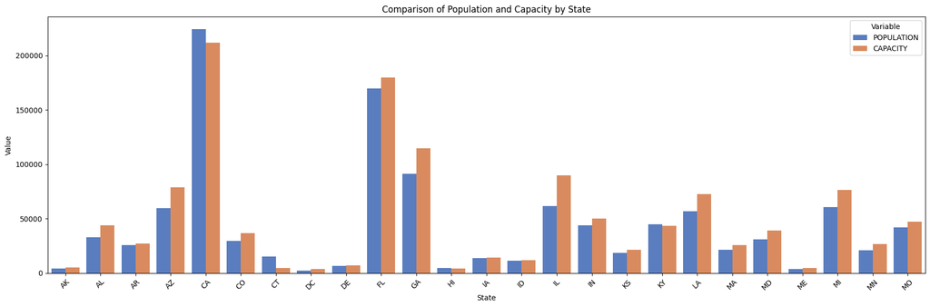

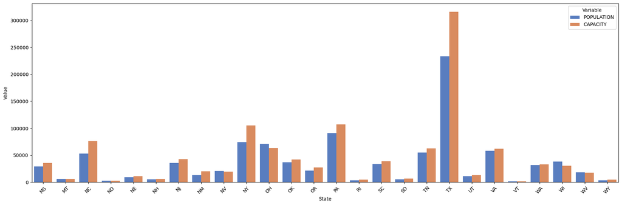

```python
# Dropping unnecessary columns
df_popcap = df_pb.drop(columns=['FACILITYID', 'TYPE', 'SECURELVL'])
df_popcap = df_popcap.groupby('STATE')[['POPULATION', 'CAPACITY']].sum().reset_index()

first_half = df_popcap.iloc[:len(df_popcap) // 2]
second_half = df_popcap.iloc[len(df_popcap) // 2:]

# Melt the DataFrame to stack 'Population' and 'Capacity' into a single column
first_half = first_half.melt(id_vars=['STATE'], var_name='Variable', value_name='Value')
second_half = second_half.melt(id_vars=['STATE'], var_name='Variable', value_name='Value')

# Create a grouped bar chart
plt.figure(figsize=(18, 6))
sns.barplot(x='STATE', y='Value', hue='Variable', data=first_half,
            palette="muted")

# Add labels and a title
plt.xlabel("State")
plt.ylabel("Value")
plt.title("Comparison of Population and Capacity by State")

# Show the plot
plt.xticks(rotation=45)  # Rotate x-axis labels for readability
plt.tight_layout()  # Ensure the labels fit within the figure
plt.legend(title="Variable", loc="upper right")
plt.show()

# Create a grouped bar chart
plt.figure(figsize=(18, 6))
sns.barplot(x='STATE', y='Value', hue='Variable', data=second_half,
            palette="muted")

# Add labels and a title
plt.xlabel("State")
plt.ylabel("Value")

# Show the plot
plt.xticks(rotation=45)  # Rotate x-axis labels for readability
plt.tight_layout()  # Ensure the labels fit within the figure
plt.legend(title="Variable", loc="upper right")
plt.show()

plt.show()
```

**Figure 6:** This figure compares the prison population of each state to its total capacity. These values were found by summing all the prison populations and capacities and grouping these values per state. A majority of states have populations under its capacity. However, some states have a larger population than their capacity. A notable example is California.

#### **3.1.7 Comparison of Population and Capacity by State (No Outliers)**

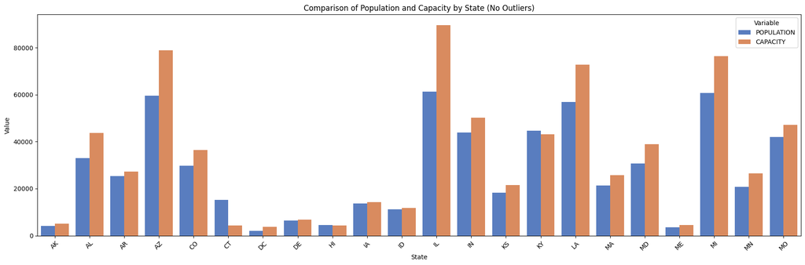

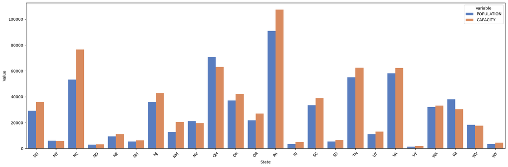

```python
first_half = first_half[~first_half['STATE'].isin(outliers)]
second_half = second_half[~second_half['STATE'].isin(outliers)]

# Create a grouped bar chart
plt.figure(figsize=(18, 6))
sns.barplot(x='STATE', y='Value', hue='Variable', data=first_half,
            palette="muted")

# Add labels and a title
plt.xlabel("State")
plt.ylabel("Value")
plt.title("Comparison of Population and Capacity by State (No Outliers)")

# Show the plot
plt.xticks(rotation=45)  # Rotate x-axis labels for readability
plt.tight_layout()  # Ensure the labels fit within the figure
plt.legend(title="Variable", loc="upper right")
plt.show()

# Create a grouped bar chart
plt.figure(figsize=(18, 6))
sns.barplot(x='STATE', y='Value', hue='Variable', data=second_half,
            palette="muted")

# Add labels and a title
plt.xlabel("State")
plt.ylabel("Value")

# Show the plot
plt.xticks(rotation=45)  # Rotate x-axis labels for readability
plt.tight_layout()  # Ensure the labels fit within the figure
plt.legend(title="Variable", loc="upper right")
plt.show()

plt.show()
```

**Figure 7:** With the outlier states removed, it is easier to see what states are over and undercrowded. Most states have a sufficient capacity for their prison population. However, Ohio, Wisconsin, Kentucky notably have larger populations than their capacity, as well as California from the last figure.

#### **3.1.8 Distribution of Prison Types (Overcrowded States)**

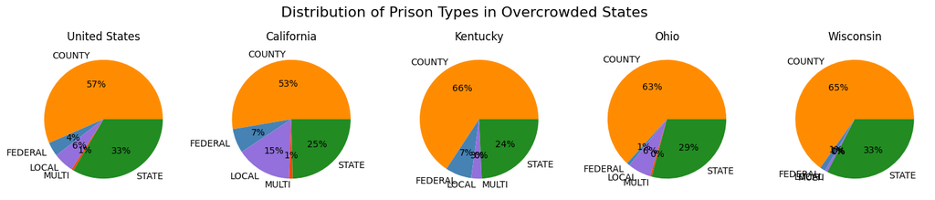

```python
colours = {'FEDERAL': 'steelblue',
    'STATE': 'forestgreen',
    'COUNTY': 'darkorange',
    'LOCAL': 'mediumpurple',
    'MULTI': 'orangered'}

type_counts = type_counts = df_pb.groupby('TYPE').size().reset_index(name='Amount')

# Get unique prison types
prison_types = type_counts['TYPE'].unique()

# Generate a list of colors based on the 'TYPE' column
colors = [colours[type] for type in prison_types]

fig, ax = plt.subplots(1, 5, figsize=(18, 6))

fig.suptitle("Distribution of Prison Types in Overcrowded States", fontsize=16)
plt.subplots_adjust(bottom = 0.5)

# Make US Subplot
type_counts = df_pb.groupby('TYPE').size().reset_index(name='Amount')
ax[0].pie(type_counts['Amount'], labels=type_counts['TYPE'], colors=colors, autopct='%.0f%%')
ax[0].set_title("United States")

# Make California Subplot
state_df = df_pb[df_pb['STATE'] == 'CA']
type_counts = state_df['TYPE'].value_counts().reset_index(name='Amount')
type_counts = type_counts.sort_values(by='TYPE')

ax[1].pie(type_counts.Amount, labels=type_counts['TYPE'], colors=colors, autopct='%.0f%%')
ax[1].set_title("California")

# Make Kentucky Subplot
state_df = df_pb[df_pb['STATE'] == 'KY']
type_counts = state_df['TYPE'].value_counts().reset_index(name='Amount')
type_counts = type_counts.sort_values(by='TYPE')

# Add new multi row as Kentucky has no multiprisons
new_data = {'TYPE': 'MULTI', 'Amount': 0}
new_row = pd.DataFrame(new_data, index=[len(type_counts)])
type_counts = pd.concat([type_counts, new_row], ignore_index=True)
type_counts = type_counts.sort_values(by='TYPE')

ax[2].pie(type_counts.Amount, labels=type_counts['TYPE'], colors=colors, autopct='%.0f%%')
ax[2].set_title("Kentucky")

# Make Ohio Subplot
state_df = df_pb[df_pb['STATE'] == 'OH']
type_counts = state_df['TYPE'].value_counts().reset_index(name='Amount')
type_counts = type_counts.sort_values(by='TYPE')

ax[3].pie(type_counts.Amount, labels=type_counts['TYPE'], colors=colors,  autopct='%.0f%%')
ax[3].set_title("Ohio")

# Make Wisconsin Subplot
state_df = df_pb[df_pb['STATE'] == 'WI']
type_counts = state_df['TYPE'].value_counts().reset_index(name='Amount')

# Add new multi row as Wisconsin has no multiprisons
new_data = {'TYPE': 'MULTI', 'Amount': 0}
new_row = pd.DataFrame(new_data, index=[len(type_counts)])
type_counts = pd.concat([type_counts, new_row], ignore_index=True)
type_counts = type_counts.sort_values(by='TYPE')
type_counts = type_counts.sort_values(by='TYPE')

ax[4].pie(type_counts.Amount, labels=type_counts['TYPE'], colors=colors, autopct='%.0f%%')
ax[4].set_title("Wisconsin")

# Create pie chart
plt.show()
```

**Figure 8:** Here, we can explore the prison type distribution for states with overcrowded prison populations. In these states, county jails make up a majority of the jails, followed by state jails. These do not match the distributions shown in the United States chart. California, Kentucky, and Ohio are all underrepresented in State jails, while Ohio and Wisconsin are also underpresented in Federal jails.

## **References**

Oak Ridge National Laboratory. (2020). Prison Boundaries [Dataset; Digital]. In HIFLD Open and HIFLD Secure. HIFLD Subcommittee. https://hifld-geoplatform.opendata.arcgis.com/datasets/geoplatform::prison-boundaries/about

Sawyer W, Wagner P. Mass Incarceration: The Whole Pie 2023. Prison Policy Initiative. Published March 14, 2023. https://www.prisonpolicy.org/reports/pie2023.html

United States Census Bureau (Director). (2021). Annual Estimates of the Resident Population for the United States, Regions, States, District of Columbia, and Puerto Rico: April 1, 2020 to July 1, 2021 [Dataset; Digital]. In United States Census. United States Government. https://www2.census.gov/programs-surveys/popest/tables/2020-2021/state/totals/